# Características que afectan la empleabilidad de los ingenieros en sistemas de la UNAH

Luis Andino

12/5/2020

## Introducción

Durante este análisis vamos a estudiar la existencia de algunas características que vuelvan propensos al desempleo a los egresados de la carrera de Ingeniería en Sistemas de la UNAH. La recolección de información se hizo mediante la aplicación de una encuesta a egresados de la carrera. Al ser parte de una generación pronta a egresar, conocemos la importancia de estudiar el panorama laboral y preocuparnos por lo que nos depara el mercado, por lo que estos resultados podrán tomarse en cuenta para mejorar nuestras costumbres y competencias, para volvernos más cercanos a lo que el mercado necesita.

```
## 'data.frame':    59 obs. of  51 variables:
##  $ Timestamp                                                                                              : Factor w/ 59 levels "2020/04/07 3:14:21 PM CDT",..: 1 2 3 4 5 6 7 8 9 10 ...
##  $ X.Cuál.es.tu.genero.                                                                                   : Factor w/ 2 levels "Hombre","Mujer": 1 1 1 1 1 1 2 1 1 1 ...
##  $ X.Qué.edad.tienes.                                                                                     : int  26 26 26 27 33 26 26 24 26 25 ...
##  $ X.De.dónde.es.tu.procedencia.                                                                          : Factor w/ 22 levels "Cerro de Hula",..: 1 10 16 15 16 16 15 15 15 22 ...
##  $ X.Estudiaste.sistemas.por.elección.propia.                                                             : Factor w/ 2 levels "No","Sí": 2 2 2 2 2 2 2 2 2 2 ...
##  $ X.Estudiaste.carreras.simultaneas.                                                                     : Factor w/ 2 levels "No","Sí": 1 1 1 1 1 1 1 1 1 1 ...
##  $ X.Te.cambiaste.de.carrera.                                                                             : Factor w/ 2 levels "No","Sí": 2 1 1 2 1 1 1 1 2 2 ...
##  $ X.Fuiste.Becado.                                                                                       : Factor w/ 2 levels "No","Sí": 1 1 1 1 1 1 1 1 1 2 ...
##  $ X.Fuiste.excelencia.académica.                                                                         : Factor w/ 2 levels "No","Sí": 1 1 1 2 1 2 1 1 1 1 ...
##  $ X.Cual.fue.tu.promedio.de.graduación.                                                                  : int  75 79 78 80 78 79 79 76 75 78 ...
##  $ X.Trabajaste.y.estudiaste.                                                                             : Factor w/ 2 levels "No","Sí": 2 2 1 1 2 1 2 1 2 2 ...
##  $ En.promedio..Cuantas.clases.por.periodo.llevabas.                                                      : int  4 4 4 4 4 4 4 4 4 4 ...
##  $ X.Cuantos.años.tardaste.en.graduarte.de.ingeniería.en.sistemas.                                        : int  8 6 7 7 10 5 5 6 8 5 ...
##  $ En.general....Los.ingenieros.con.los.que.metiste.clases.eran.buenos.dando.la.clase.                    : Factor w/ 5 levels "El 40%  o menos eran buenos dando la clase",..: 2 4 2 3 3 1 5 4 3 1 ...
```

[output cut: 37 more lines]

Como resultado de la aplicación de la encuesta, se capturaron 59 observaciones y 51 columnas, organizandolas en las siguientes categorías:

```
1. Información demográfica.
2. Rendimiento universitario.
3. Post-universidad.
4. Hardskills.
5. Softskills.
```

De manera recopilatoria, a continuación un resumen de la información recabada:

```r
summary(survey)
```

```
##                      Timestamp  X.Cuál.es.tu.genero. X.Qué.edad.tienes.
##  2020/04/07 3:14:21 PM CDT: 1   Hombre:47            Min.   :23.00
##  2020/04/07 3:32:48 PM CDT: 1   Mujer :12            1st Qu.:25.50
##  2020/04/07 5:01:27 PM CDT: 1                        Median :27.00
##  2020/04/07 5:07:30 PM CDT: 1                        Mean   :27.41
##  2020/04/07 5:24:08 PM CDT: 1                        3rd Qu.:29.00
##  2020/04/07 5:32:12 PM CDT: 1                        Max.   :38.00
##  (Other)                  :53
##    X.De.dónde.es.tu.procedencia. X.Estudiaste.sistemas.por.elección.propia.
##  Tegucigalpa      :22            No: 2
##  Tegucigalpa      :10            Sí:57
##  Francisco Morazan: 3
##  FM               : 2
##  Intibuca         : 2
##  Olancho          : 2
##  (Other)          :18
##  X.Estudiaste.carreras.simultaneas. X.Te.cambiaste.de.carrera. X.Fuiste.Becado.
##  No:56                              No:39                      No:54
##  Sí: 3                              Sí:20                      Sí: 5
##
##
##
##
##
##  X.Fuiste.excelencia.académica. X.Cual.fue.tu.promedio.de.graduación.
##  No:42                          Min.   :  66.0
##  Sí:17                          1st Qu.:  76.5
##                                 Median :  78.0
##                                 Mean   : 111.1
##                                 3rd Qu.:  80.0
##                                 Max.   :2019.0
##
##  X.Trabajaste.y.estudiaste. En.promedio..Cuantas.clases.por.periodo.llevabas.
##  No:29                      Min.   :3
##  Sí:30                      1st Qu.:4
##                             Median :4
##                             Mean   :4
##                             3rd Qu.:4
##                             Max.   :5
##
```

[output cut: 265 more lines]

```
##  No:30                         No:11
##  Sí:29                         Sí:48
##
##
##
##
##
##  X.Te.molestas.con.facilidad.
##  No:39
##  Sí:20
##
##
##
##
##
```

## Tratamiento de columnas

```
##  [1] "Timestamp"
##  [2] "X.Cuál.es.tu.genero."
##  [3] "X.Qué.edad.tienes."
##  [4] "X.De.dónde.es.tu.procedencia."
##  [5] "X.Estudiaste.sistemas.por.elección.propia."
##  [6] "X.Estudiaste.carreras.simultaneas."
##  [7] "X.Te.cambiaste.de.carrera."
##  [8] "X.Fuiste.Becado."
##  [9] "X.Fuiste.excelencia.académica."
## [10] "X.Cual.fue.tu.promedio.de.graduación."
## [11] "X.Trabajaste.y.estudiaste."
## [12] "En.promedio..Cuantas.clases.por.periodo.llevabas."
## [13] "X.Cuantos.años.tardaste.en.graduarte.de.ingeniería.en.sistemas."
## [14] "En.general....Los.ingenieros.con.los.que.metiste.clases.eran.buenos.dando.la.clase."
## [15] "X.Estás.satisfecho.con.los.conocimientos.que.te.impartieron.en.la.universidad."
```

[output cut: 36 more lines]

```
##  [1] Timestamp
##  [2] X.Cuál.es.tu.genero.
##  [3] X.Qué.edad.tienes.
##  [4] X.De.dónde.es.tu.procedencia.
##  [5] X.Estudiaste.sistemas.por.elección.propia.
##  [6] X.Estudiaste.carreras.simultaneas.
##  [7] X.Te.cambiaste.de.carrera.
##  [8] X.Fuiste.Becado.
##  [9] X.Fuiste.excelencia.académica.
## [10] X.Cual.fue.tu.promedio.de.graduación.
## [11] X.Trabajaste.y.estudiaste.
## [12] En.promedio..Cuantas.clases.por.periodo.llevabas.
## [13] X.Cuantos.años.tardaste.en.graduarte.de.ingeniería.en.sistemas.
## [14] En.general....Los.ingenieros.con.los.que.metiste.clases.eran.buenos.dando.la.clase.
## [15] X.Estás.satisfecho.con.los.conocimientos.que.te.impartieron.en.la.universidad.
```

[output cut: 37 more lines]

```
##  [1] timestamp                     genero
##  [3] edad                          procedencia
##  [5] eleccion_estudio              carrera_simultanea
##  [7] cambio_carrera                becado
##  [9] excelencia_academica          promedio_graduacion
## [11] trabajo_y_estudio             clases_por_periodo
## [13] tiempo_graduacion             rendimiento_docente
## [15] calidad_contenido             tecnologias_unah
## [17] tecnologias_autodidacta       actividades_extracurriculares
## [19] areas_no_favoritas            areas_favoritas
## [21] preparacion_practica          portafolio
## [23] conocimientos_ayudaron        anio_graduacion
## [25] mes_graduacion                trabajo_por_carrera
## [27] gustar_practica               ofrecieron_trabajo_practica
## [29] trabajo_practica              tecnologias_mercado_laboral
## [31] actualizacion_tecnologias     trabajo_actual
## [33] trabajo_ingeniero_sistemas    meses_desempleado
## [35] trabajo_area_preferencia      trabajo_pre_graduacion
## [37] nivel_ingles                  nivel_programacion
## [39] nivel_redes                   nivel_servidores
## [41] nivel_disenio                 nivel_admin
## [43] lider_proyectos               nivel_proactividad
## [45] nivel_autodidacta             expositor
## [47] negociador                    lider
## [49] introvertido                  competitivo
## [51] irritabilidad
## 51 Levels: actividades_extracurriculares ... trabajo_y_estudio
```

```
##  [1] "Timestamp"
##  [2] "X.Cuál.es.tu.genero."
##  [3] "X.Qué.edad.tienes."
##  [4] "X.De.dónde.es.tu.procedencia."
##  [5] "X.Estudiaste.sistemas.por.elección.propia."
##  [6] "X.Estudiaste.carreras.simultaneas."
##  [7] "X.Te.cambiaste.de.carrera."
##  [8] "X.Fuiste.Becado."
##  [9] "X.Fuiste.excelencia.académica."
## [10] "X.Cual.fue.tu.promedio.de.graduación."
## [11] "X.Trabajaste.y.estudiaste."
## [12] "En.promedio..Cuantas.clases.por.periodo.llevabas."
## [13] "X.Cuantos.años.tardaste.en.graduarte.de.ingeniería.en.sistemas."
## [14] "En.general....Los.ingenieros.con.los.que.metiste.clases.eran.buenos.dando.la.clase."
## [15] "X.Estás.satisfecho.con.los.conocimientos.que.te.impartieron.en.la.universidad."
```

[output cut: 36 more lines]

```
##  [1] "timestamp"                     "genero"
##  [3] "edad"                          "procedencia"
##  [5] "eleccion_estudio"              "carrera_simultanea"
##  [7] "cambio_carrera"                "becado"
##  [9] "excelencia_academica"          "promedio_graduacion"
## [11] "trabajo_y_estudio"             "clases_por_periodo"
## [13] "tiempo_graduacion"             "rendimiento_docente"
## [15] "calidad_contenido"             "tecnologias_unah"
## [17] "tecnologias_autodidacta"       "actividades_extracurriculares"
## [19] "areas_no_favoritas"            "areas_favoritas"
## [21] "preparacion_practica"          "portafolio"
## [23] "conocimientos_ayudaron"        "anio_graduacion"
## [25] "mes_graduacion"                "trabajo_por_carrera"
## [27] "gustar_practica"               "ofrecieron_trabajo_practica"
## [29] "trabajo_practica"              "tecnologias_mercado_laboral"
## [31] "actualizacion_tecnologias"     "trabajo_actual"
## [33] "trabajo_ingeniero_sistemas"    "meses_desempleado"
## [35] "trabajo_area_preferencia"      "trabajo_pre_graduacion"
## [37] "nivel_ingles"                  "nivel_programacion"
## [39] "nivel_redes"                   "nivel_servidores"
## [41] "nivel_disenio"                 "nivel_admin"
## [43] "lider_proyectos"               "nivel_proactividad"
## [45] "nivel_autodidacta"             "expositor"
## [47] "negociador"                    "lider"
## [49] "introvertido"                  "competitivo"
## [51] "irritabilidad"
```

```
##  [1] 4 4 4 4 4 4 4 4 4 4 4 4 4 4 4 4 4 4 4 3 4 5 4 4 4 4 4 4 3 5 4 4 3 4 4 3 3 4
## [39] 4 5 4 4 3 4 3 4 5 5 4 5 4 3 5 4 4 4 4 4 5
```

### Pasando a factor:

#### edad

```
##  int [1:59] 26 26 26 27 33 26 26 24 26 25 ...
```

```
##  Factor w/ 11 levels "23","24","25",..: 4 4 4 5 10 4 4 2 4 3 ...
```

#### promedio_graduacion

```
##  int [1:59] 75 79 78 80 78 79 79 76 75 78 ...
```

```
##  Factor w/ 17 levels "66","69","72",..: 5 9 8 10 8 9 9 6 5 8 ...
```

### meses_desempleado

```
##  [1]    0    0    2    4    4    0    0    7    1    0    0    0    2    0    0
## [16]    0    2    0    6    1    1    3   11    0    0    0    0    3    0    0
## [31]    0    0    0    0    0    0    0    3    0    0    1    5    1    0    0
## [46]    2    0   10    6    0    9    0    0    0 1000    2    0    0    0
```

```
##  Factor w/ 12 levels "0","1","2","3",..: 1 1 3 5 5 1 1 8 2 1 ...
```

### Limpiando valores nulos

De manera tradicional, uno de los tratamientos más convencionales que se le realiza a la información para su análisis, es la detección de valores nulos.

```
##                      timestamp     genero        edad               procedencia
##  2020/04/07 3:14:21 PM CDT: 1   Hombre:47   26     :11   Tegucigalpa      :22
##  2020/04/07 3:32:48 PM CDT: 1   Mujer :12   29     : 9   Tegucigalpa      :10
##  2020/04/07 5:01:27 PM CDT: 1               27     : 7   Francisco Morazan: 3
##  2020/04/07 5:07:30 PM CDT: 1               28     : 7   FM               : 2
##  2020/04/07 5:24:08 PM CDT: 1               25     : 6   Intibuca         : 2
##  2020/04/07 5:32:12 PM CDT: 1               24     : 5   Olancho          : 2
##  (Other)                  :53               (Other):14   (Other)          :18
##  eleccion_estudio carrera_simultanea cambio_carrera becado
##  No: 2            No:56              No:39          No:54
##  Sí:57            Sí: 3              Sí:20          Sí: 5
##
##
##
##
##
##  excelencia_academica promedio_graduacion trabajo_y_estudio clases_por_periodo
##  No:42                78     :12          No:29             Min.   :3
##  Sí:17                79     :11          Sí:30             1st Qu.:4
##                       75     : 8                            Median :4
##                       80     : 5                            Mean   :4
##                       77     : 4                            3rd Qu.:4
##                       81     : 4                            Max.   :5
##                       (Other):15
##  tiempo_graduacion                                 rendimiento_docente
##  Min.   : 5.000    El 40%  o menos eran buenos dando la clase: 8
##  1st Qu.: 6.000    El 50% eran buenos dando la clase         :10
##  Median : 7.000    El 60% eran buenos dando la clase         :17
##  Mean   : 7.102    El 70% eran buenos dando la clase         :20
##  3rd Qu.: 8.000    El 90% eran buenos dando la clase         : 4
##  Max.   :10.000
##
##  calidad_contenido
##  No:30
##  Sí:29
##
##
##
##
##
```

[output cut: 97 more lines]

```
##  No:19             No:20     No:28      No:25   No:30        No:11
##  Sí:40             Si:39     Sí:31      Sí:34   Sí:29        Sí:48
##
##
##
##
##
##  irritabilidad
##  No:39
##  Sí:20
##
##
##
##
##
```

```
## [1] "timestamp"
## [1] "genero"
## [1] "edad"
## [1] "procedencia"
## [1] "eleccion_estudio"
## [1] "carrera_simultanea"
## [1] "cambio_carrera"
## [1] "becado"
## [1] "excelencia_academica"
## [1] "promedio_graduacion"
## [1] "trabajo_y_estudio"
## [1] "clases_por_periodo"
## [1] "tiempo_graduacion"
## [1] "rendimiento_docente"
## [1] "calidad_contenido"
```

[output cut: 36 more lines]

## Análisis descriptivo

### Género

Nuestras respuestas vienen en su mayoría de un público masculino, sin dejar de tener la aparición de una considerable participación femenina.En este momento no es una sorpresa que existan más personas de género masculino dentro de nuestra carrera, eso se pudo inferir desde el análisis de la matrícula de los últimos años y de los egresados anuales, sin embargo, existe una tendencia a la diversificación en lo que a género se refiere.

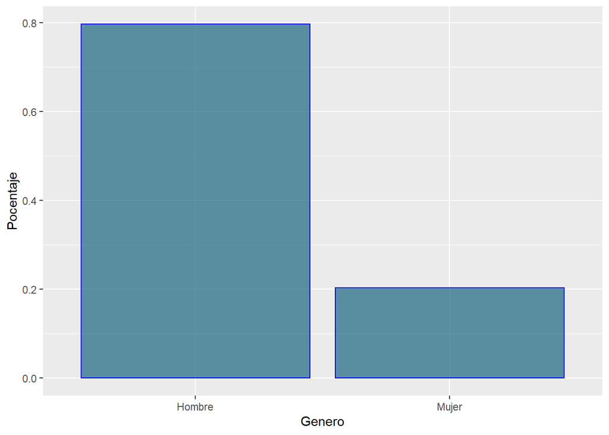

### Proactividad

Una persona proactiva sin dudas se destaca de las demás en el caso de la ingeniería en donde constantemente hay que proponer soluciones es una habilidad que se tiene que desarrollar.Se observan los niveles de proactividad presentados a los estudiantes recién graduados en donde 1 es el más bajo y 5 el más alto, no se observan coincidencias con el valor más bajo por lo que en valores de 3 hacia arriba son los números más relevantes por lo tanto se puede concluir que son habilidades que utilizan a diario en el ámbito que se desenvuelven.

```
##  [1] 5 4 4 2 3 3 5 3 4 5 5 5 5 4 3 4 5 4 3 4 3 4 3 4 4 4 3 3 3 4 4 3 4 4 3 4 5 4
## [39] 5 4 2 3 5 3 3 3 5 4 4 3 3 3 4 4 3 4 3 3 3
```

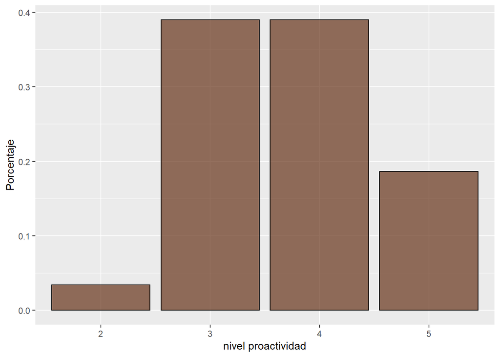

### Promedio de graduación

Se aprecia que un porcentaje considerablemente mayoritario de nuestros encuestados figuran bajo el preciado 80% que los categorizaría como estudiantes de excelencia académica, y este hecho podría afectar negativamente en un escenario de solicitud de empleo en el que exista una considerable cantidad de postulantes, en este caso, lo más probable es pensar que los que tengan mejor promedio tengan más posibilidades.

```
##    Min. 1st Qu.  Median    Mean 3rd Qu.    Max.
##   66.00   76.50   78.00   78.22   80.00   90.00
```

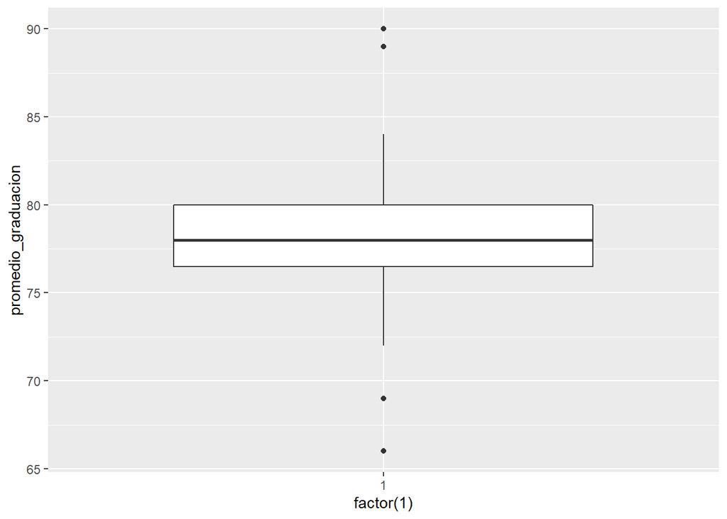

### Hardskills

El área común más débil es el nivel de inglés, seguidamente del nivel de redes y de administración curiosamente el nivel de programación no obtiene datos en el apartado de “poco”.

En el apartado de neutro se puede observar que en casi todas las áreas el nivel de neutro es bastante relevante lo que lleva pensar que se imparte lo necesario de conocimientos en las áreas mencionadas. El análisis del apartado de “muy bien” es el dato de menos relevancia o frecuente, en cambio en el apartado de “más que poco” lo lidera el nivel de redes seguido del nivel de diseño e inglés. En el apartado de “bien” se hace notar el área favorita de los egresados de la carrera de ingeniería en sistemas que es la programación seguida de cerca del nivel de diseño.

```
##  [1] Sí Sí Sí No Sí Sí No Sí Sí Sí Sí Sí Sí Sí No Sí Sí Sí No Sí No No No Sí Sí
## [26] Sí Sí Sí Sí No Sí No Sí Sí No Sí Sí Sí No Sí No Sí Sí Sí Sí No Sí Sí No No
## [51] Sí Sí Sí Sí No Sí No No No
## Levels: No Sí
```

```
## [1] 0.2372881
```

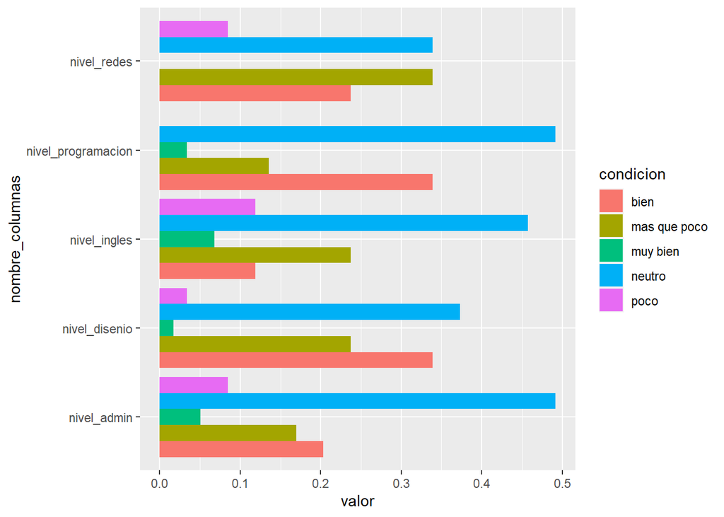

## Correlaciones

Un estudio correlacional determina si dos variables están correlacionadas o no. Esto significa analizar si un aumento o disminución en una variable coincide con un aumento o disminución en la otra variable. A continuación, relacionaremos las variables descritas anteriormente y buscaremos alguna correspondencia entre ellas.

### Género - Proactividad

El motivo de esta correlación, es tratar de inferir si existe una correspondencia entre la percepción personal del nivel de proactividad de una persona egresada de la carrera de ingeniería en sistemas de la UNAH, en función de su género.

#### Hipótesis

```
H_0: El nivel de proactividad y el género son independientes.
H_A: El nivel de proactividad y el género son dependientes.
```

```
##
##        Hombre     Mujer
##   2 0.5000000 0.5000000
##   3 0.8695652 0.1304348
##   4 0.7391304 0.2608696
##   5 0.8181818 0.1818182
```

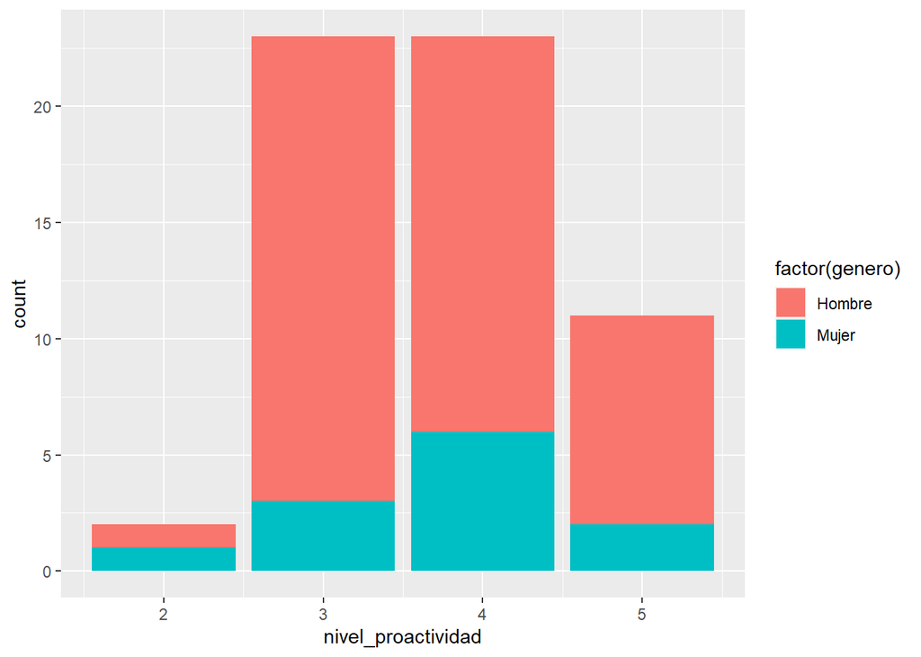

```
##
##  Pearson's Chi-squared test
##
## data:  table(survey$nivel_proactividad, survey$genero)
## X-squared = 2.3421, df = 3, p-value = 0.5045
```

### Promedio - Proactividad

Este análisis se lleva a cabo con la finalidad de verificar si existe una relación entre la proactividad de un estudiante y su índice académico, pues mucho se dice que quienes más ponen de sí mismos, mejores calificaciones podrían tener.

#### Normalidad de la distribución de promedio de graduación

```
H_0: Nuestra distribución es normal.
H_A: Nuestra distribución no es normal.
```

Al iniciar el análisis, nos encontramos con un par de valores atípicos que aumentan el error demasiado. Arrojándonos un p-value demasiado bajo.

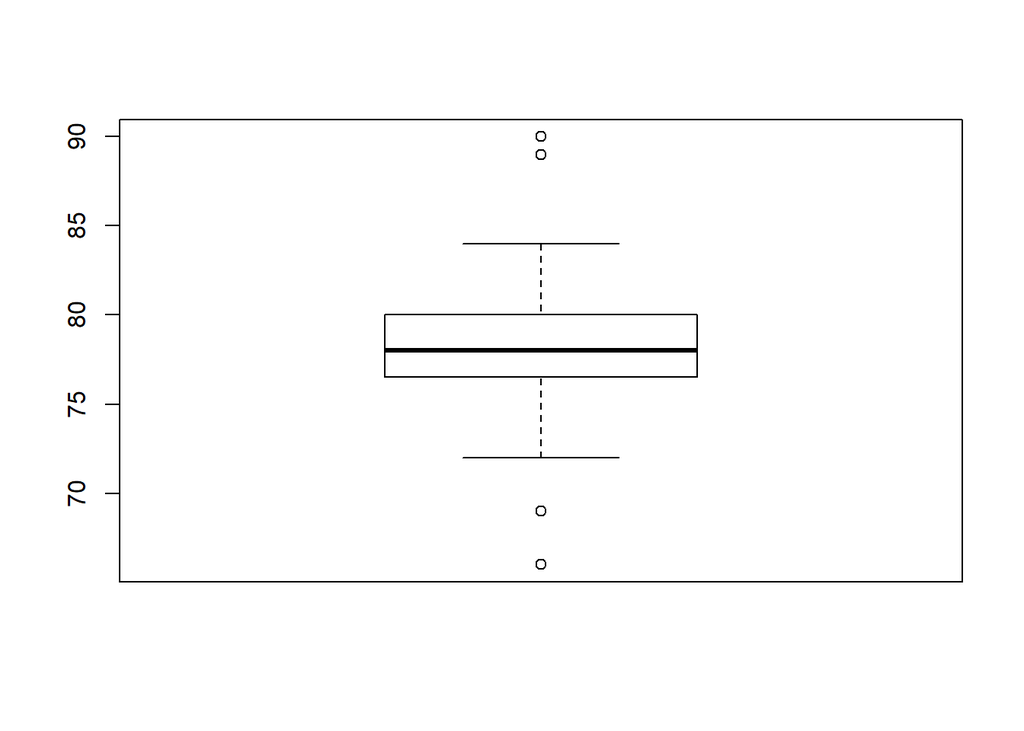

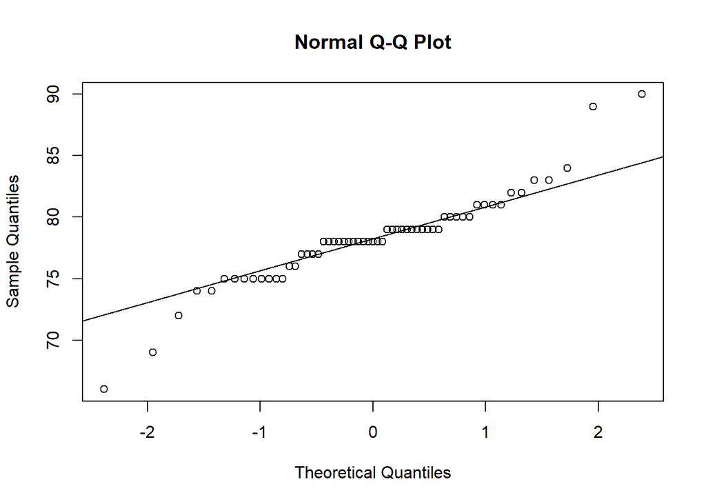

```
##
##  Shapiro-Wilk normality test
##
## data:  survey$promedio_graduacion
## W = 0.91713, p-value = 0.0006588
```

Considerando esta incidencia, nos dispondremos a cambiar esos pocos valores atípicos que nos llenan el análisis de error. De esta forma, obtenemos un p-value que nos permite no rechazar nuestra hipótesis nula (H_O).

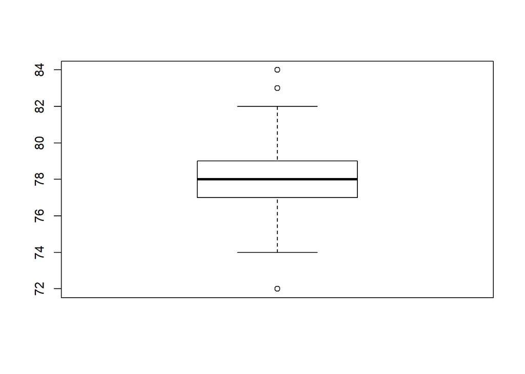

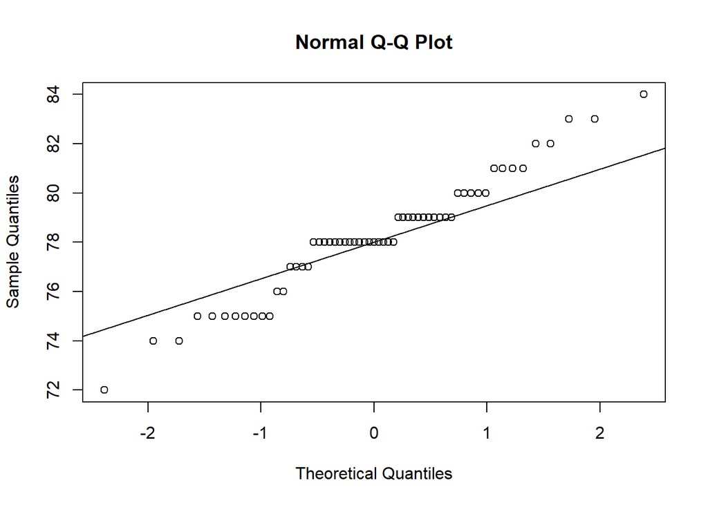

```
##
##  Shapiro-Wilk normality test
##
## data:  survey$promedio_graduacion
## W = 0.96257, p-value = 0.06677
```

#### Normalidad de las agrupaciones

A continuación dividiremos nuestra distribución por su promedio en función de nuestra variable categórica (Nivel de proactividad). De la misma manera analizaremos su normalidad bajo la misma hipótesis nula (H_0).

##### Agrupación de nivel de proactividad 2-4 (Baja)

Con un p-value superior a 0.05 no podemos rechazar la hipótesis nula (H_0).

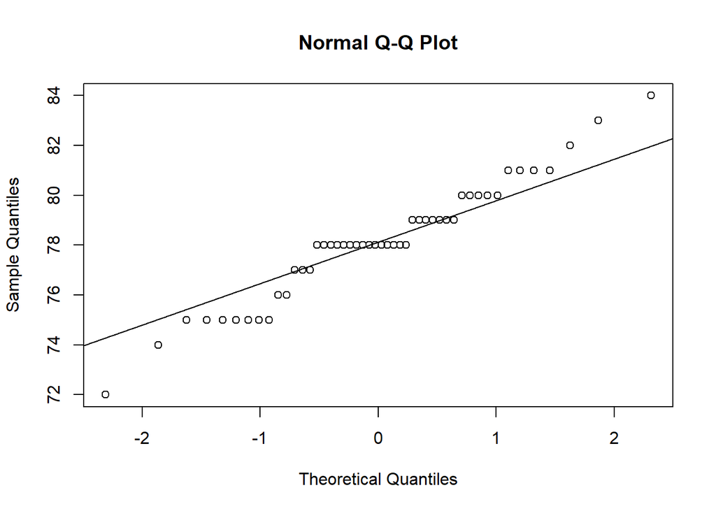

```
##
##  Shapiro-Wilk normality test
##
## data:  gp_bajo$promedio_graduacion
## W = 0.96248, p-value = 0.1272
```

##### Agrupación de nivel de proactividad 5 (Alto)

De la misma manera que en el caso anterior, el p-value es mayor a 0.05, por lo que no rechazamos la hipótesis nula (H_0).

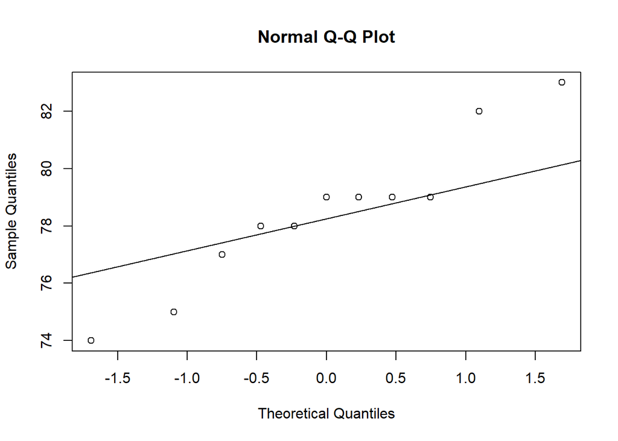

```
##
##  Shapiro-Wilk normality test
##
## data:  gp_alto$promedio_graduacion
## W = 0.93723, p-value = 0.4885
```

#### Homocedasticidad de las agrupaciones

Con un p-value mayor a 0.05 no rechazamos la hipótesis nula y suponemos homogeneidad de las varianzas de ambos grupos.

```
##
##  F test to compare two variances
##
## data:  gp_bajo$promedio_graduacion and gp_alto$promedio_graduacion
## F = 0.82116, num df = 47, denom df = 10, p-value = 0.6092
## alternative hypothesis: true ratio of variances is not equal to 1
## 95 percent confidence interval:
##  0.254221 1.917285
## sample estimates:
## ratio of variances
##          0.8211612
```

#### Análisis de medias de las agrupaciones

Con un p-vaue superior a 0.05, no podemos rechazar nuestra hipótesis nula. Por lo tanto suponemos que las medias son iguales, y en función de ello, no podemos concluir, ya que ambos grupos tienen un comportamiento similar.

```
##
##  Two Sample t-test
##
## data:  gp_bajo$promedio_graduacion and gp_alto$promedio_graduacion
## t = -0.40727, df = 57, p-value = 0.6853
## alternative hypothesis: true difference in means is not equal to 0
## 95 percent confidence interval:
##  -1.949844  1.290753
## sample estimates:
## mean of x mean of y
##  78.12500  78.45455
```

### Hardskills

Este análisis se realiza para intentar encontrar una relación entre las habilidades técnicas de los egresados, es decir, para saber si existe una tendencia que indique si algunas habilidades técnicas se ligan a unas y repelen a otras.

#### Nivel de redes

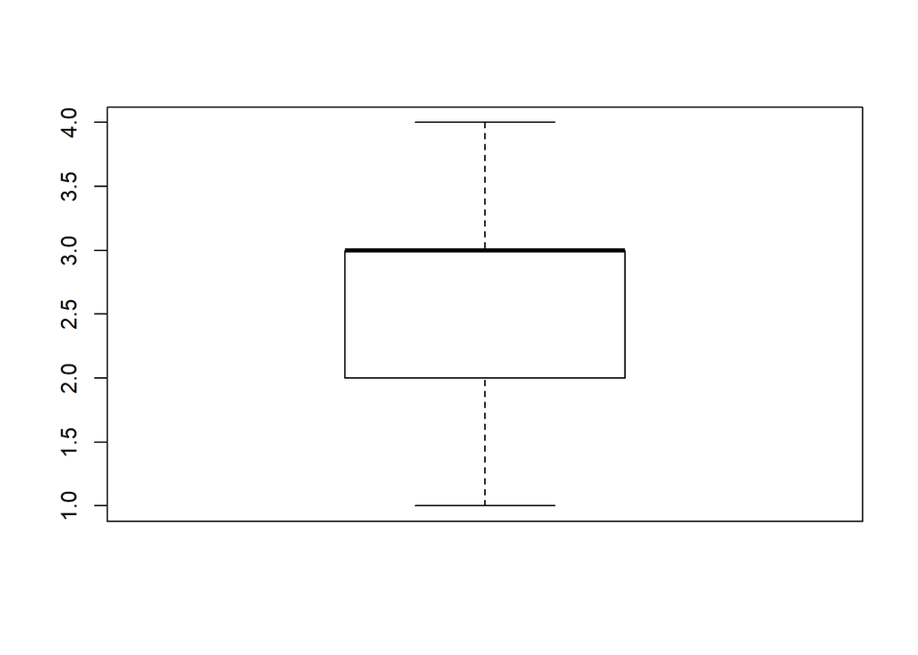

#### Nivel de programacion

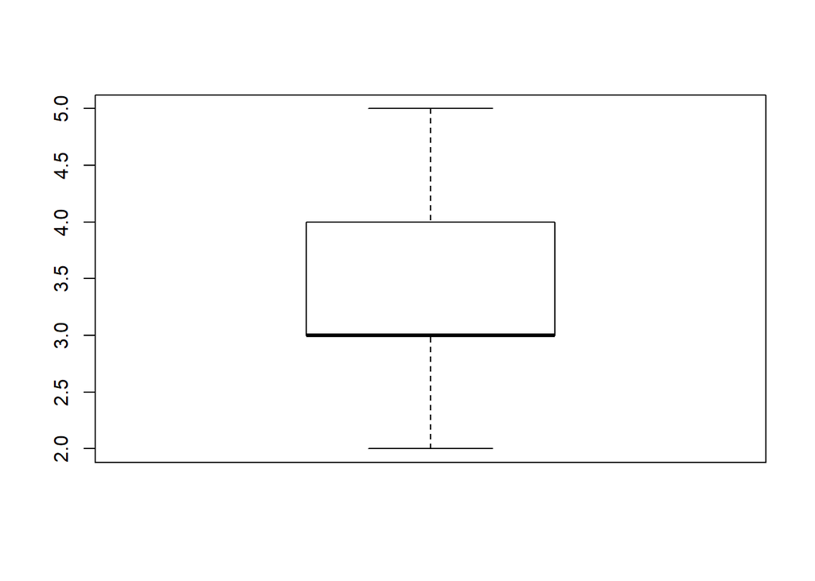

#### Nivel de inglés

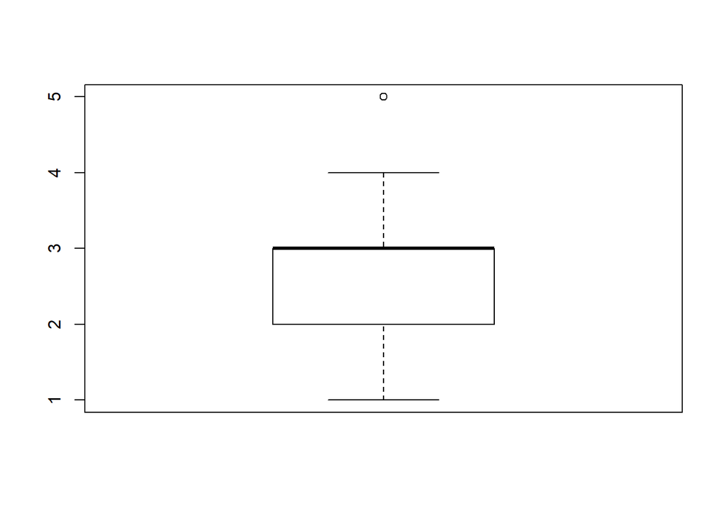

#### Nivel de administración

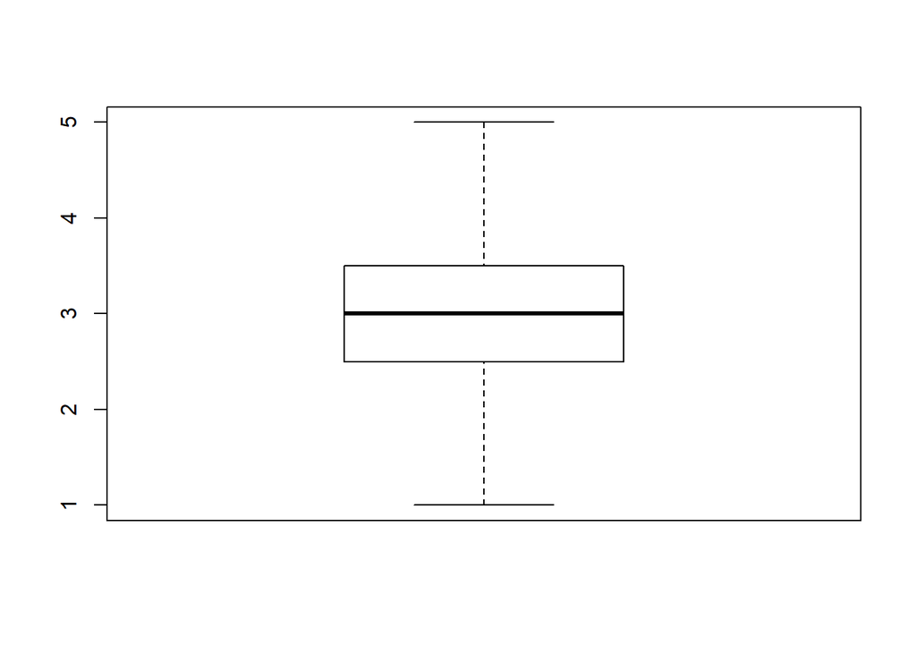

#### Nivel de diseño

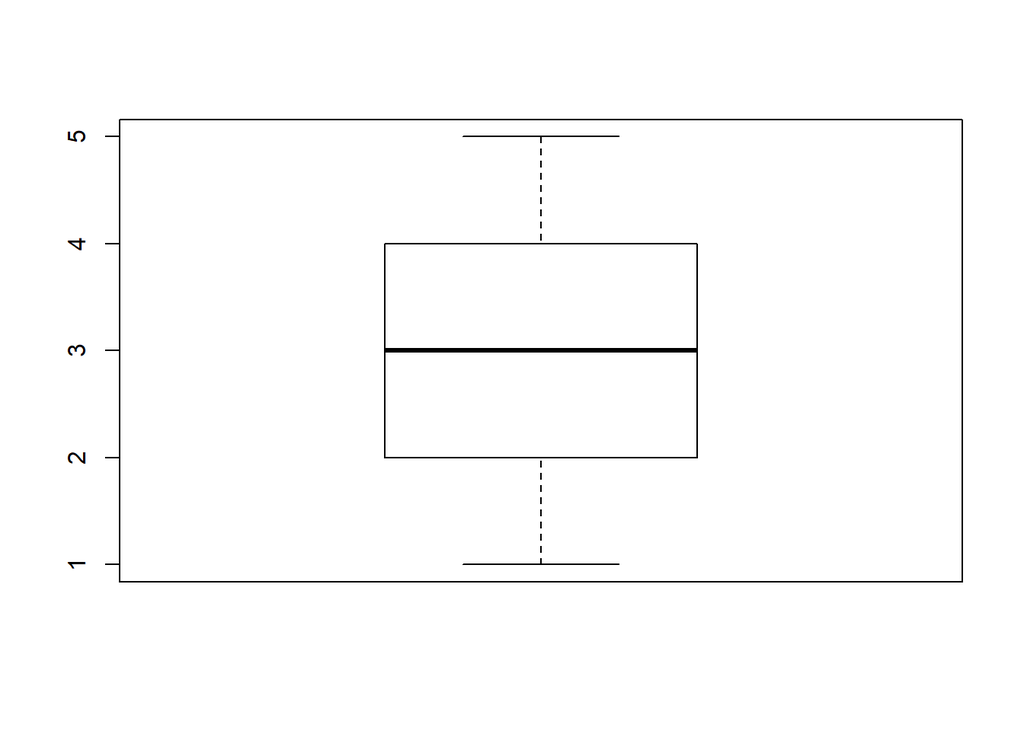

#### Correlación entre habilidades

En los gráficos siguientes se representarán los resultados del análisis correlacional entre cada una de las áreas, destacando particularmente el alejamiento encontrado entre el inglés y las demás habilidades.

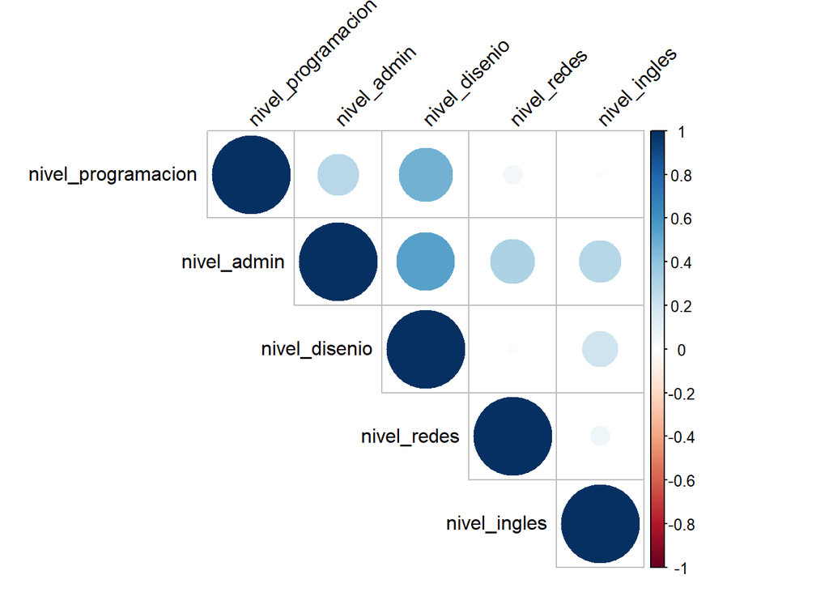

Es en esta sección donde es más visible la imposibilidad de conclusión con respecto al inglés y las demás habilidades, pues el ángulo obtenido y su respectivo coseno nos arrojarán un valor cercano a cero. Sin embargo, si podemos ver una cercanía entre las áreas de redes y programación, así como de administración y diseño.

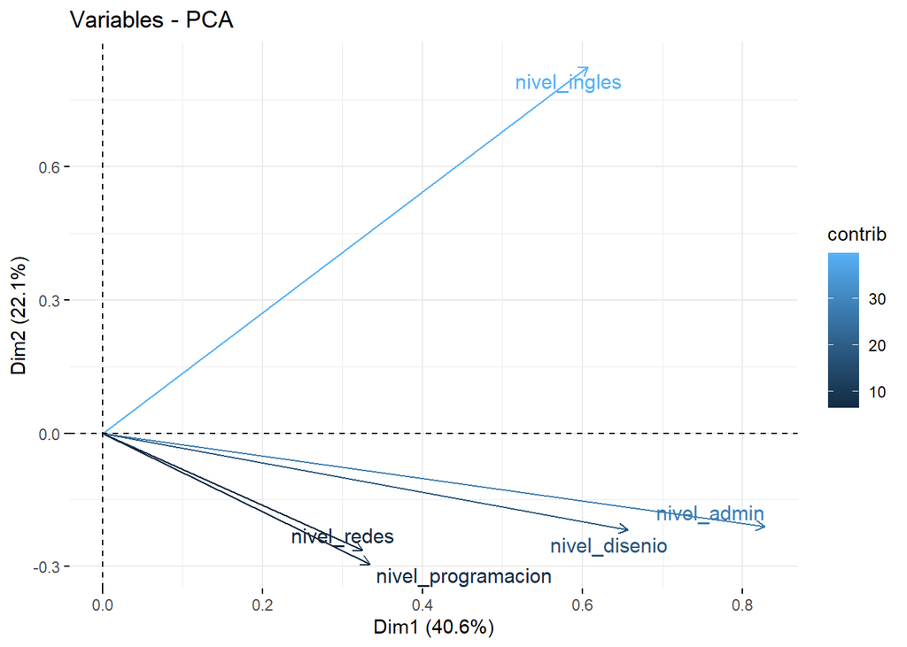

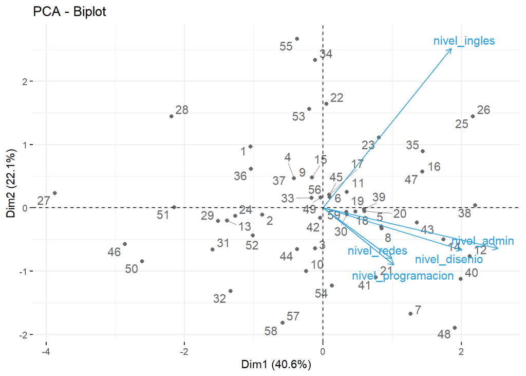

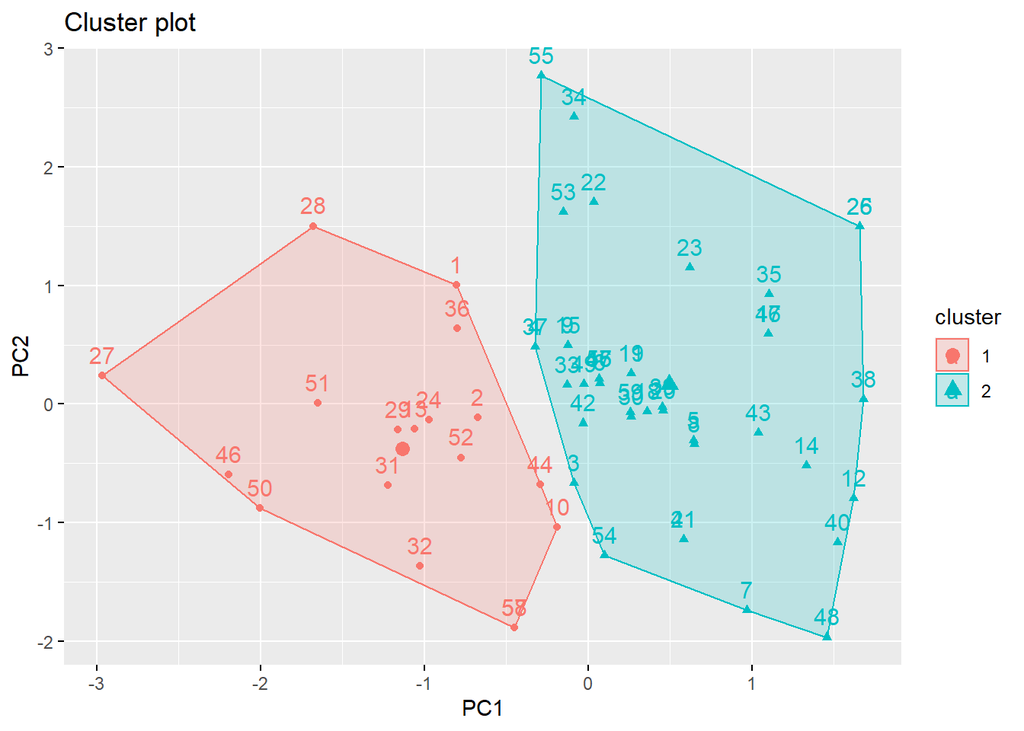

```
##  [1] 1 1 2 2 2 2 2 2 2 1 2 2 1 2 2 2 2 2 2 2 2 2 2 1 2 2 1 1 1 2 1 1 2 2 2 1 2 2
## [39] 2 2 2 2 2 1 2 1 2 2 2 1 1 1 2 2 2 2 1 1 2
```

### Análisis explicativo

#### Definición de la variable de respuesta

En nuestro caso de estudio la variable de respuesta y variable dependiente será la empleabilidad de los graduados de ingeniería en sistemas, dicha variable está definida en nuestra encuesta por la siguiente pregunta:

```
¿Actualmente tienes trabajo?
```

#### Aplicación de regresión logística para los factores más importantes

##### Encontrar coeficientes para predicción

Nota: la variable encuesta es el dataframe que almacena los resultados de nuestra encuesta.

##### Cálculo de overall

Encuentra el nivel de importancia de las variables al momento del calcular un valor predictivo de nuevos registros.

```
##
##         0         1
## 0.8305085 0.1694915
```

```
##         Overall                             col
## 1  9.497282e-01                nivel_servidores
## 2  9.329415e-01              nivel_programacion
## 3  6.056323e-01                    nivel_ingles
## 4  4.580742e-01 actividades_extracurricularesSí
## 5  6.198238e-02                     generoMujer
## 6  2.715490e-03                          edad38
## 7  2.672882e-03                          edad33
## 8  2.298503e-03                          edad24
## 9  2.242505e-03                          edad25
## 10 2.218466e-03                          edad26
## 11 2.177387e-03                          edad29
## 12 6.450068e-05                          edad28
## 13 2.149704e-05                          edad30
## 14 1.435887e-05                          edad31
## 15 1.081137e-05                          edad27
```

##### Gráficos

A continuación, se tratará de contestar la siguiente pregunta de investigación ¿Qué características poseen los graduados de ingeniería en sistemas que están actualmente contratados? Según el análisis de los factores y gráficos la mayoría de empleados tienen las siguientes características: un nivel de inglés razonable, una edad menor a 30 años, un nivel aceptable de administración de servidores, entre otros.

```
Notas para la lectura de gráficos: El 1 significa que no posee empleo y el cero significa que si lo tiene.
```

###### La mayoría de los egresados con empleo tienen una edad menor a 30 años

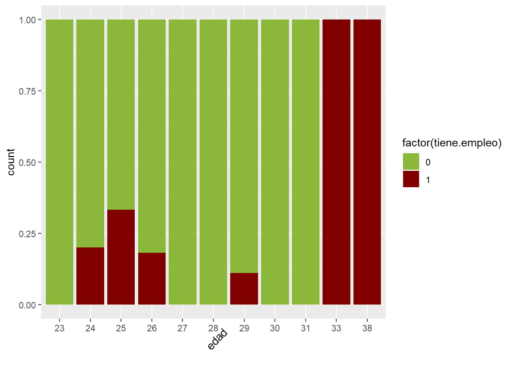

###### La empleabilidad es del 100% si posee un nivel de ingles alto

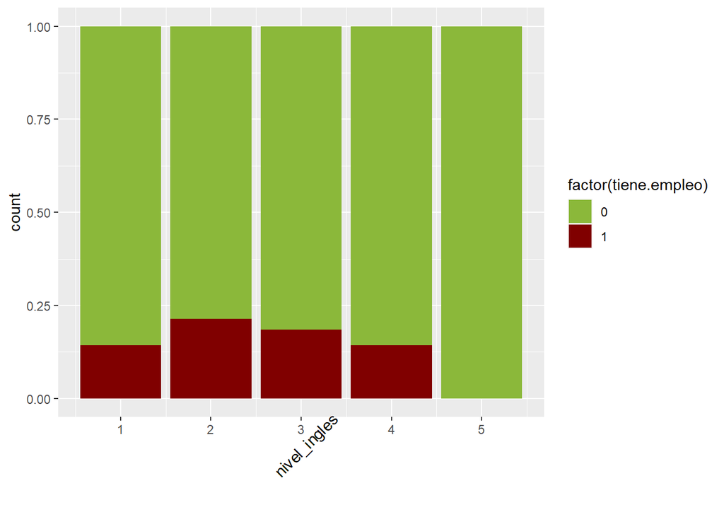

###### La empleabilidad de los graduados te tienen conocimientos de administración de servidores es mayor a los que no tienen dicho conocimiento

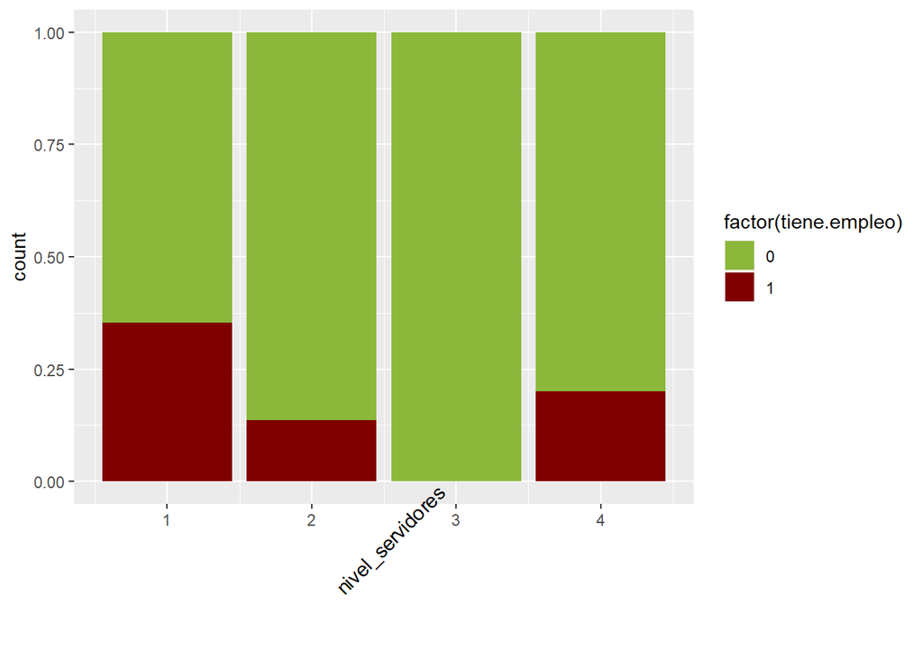

### Solución tecnológica

#### Comunicación

Nuestra solución tecnológica hace uso de la plataforma de AWS. Consiste en 3 partes de comunicación esencial para su efectiva funcionalidad. Primero tenemos la conexión Seguro social y UNAH que es donde vamos a compilar información importante del estudiante, seguido de Hadoop donde toda la información que obtengamos del seguro social y de la unah será manipulada en esta parte de la solución tecnológica.

Y tenemos el portal del estudiante donde este estará almacenado en un EC2 en aws y se usará elastic beanstalk para desarrollar esta parte de la infraestructura. En el portal es donde el estudiante estará proporcionando su CV para poder ser analizado en hadoop con la información de la UNAH y del seguro social. Una vez analizada la información todo será regresado al portal del estudiante en el cual estará el estado de empleabilidad para que el lo vea o si se decide sera solo de acceso administrativo.

##### Seguro social - UNAH

Una vez que el estudiante esté listo para su práctica profesional y abra expediente en las oficinas de ingeniería en sistemas, el tendrá que enviar su CV a nuestra plataforma. Una vez tenido el CV inicia el proceso de recopilación de información. La información del CV será manipulada en Hadoop Mahout.

[figure not shown]

[figure not shown]

Una vez que el estudiante esté listo para su práctica profesional y abra expediente en las oficinas de ingeniería en sistemas, el tendrá que enviar su CV a nuestra plataforma. Una vez tenido el CV inicia el proceso de recopilación de información. La información del CV será manipulada en Hadoop Mahout.

##### Portal web - AWS Elastic beanstalk

[figure not shown]

Diagrama de la arquitectura de la solución tecnológica 3

El portal web estará montando en los servidores de AWS y estaremos usando Elastic Beanstalk por razones de organización. Elastic Beanstalk es solo una integración con muchas otras tecnologías dentro de los servicios que ofrece AWS que en nuestro caso nos ayudará a mantener organizado nuestro trabajo y nos ahorra tiempo de configuración.

Si bien es cierto, el portal sólo lo estarán viendo los estudiantes o los administradores de la carrera de ingeniería en sistemas, a nosotros los desarrolladores nos servirá para integrar toda la información que viene de hadoop y que va para hadoop.

##### Hadoop - AWS Glue

[figure not shown]

Diagrama de la arquitectura de la solución tecnológica 4

Una vez consumidas las APIs del Seguro Social y de la UNAH esta información se estar guardando en una base de datos relacional. Donde se estará utilizando AWS Glue como herramienta de Extracción, carga y transformación. Antes de enviar la información a Hadoop primero preparamos los datos y despues enviemos a Hadoop.

Hadoop es un set de tecnologías para aplicaciones en forma de cluster que mayormente se utilizan para el trabajo de datos masivos. En nuestro caso estamos interesado en la interacción que tiene con computación distribuida y las capabilidades de la herramienta madura como Mahout para el desarrollo de algoritmos de aprendizaje automático.

Una vez nuestra información se encuentre de forma ordenada en AWS glue, está pasara a Hadoop donde sera utlizara para entrenar y posteriormente se utilizará para decidir el nivel de empleabilidad de los CVs de diferentes alumnos de la carrera de ingeniería en sistema de la UNAH.

[figure not shown]

Diagrama de la arquitectura de la solución tecnológica

#### Presupuesto

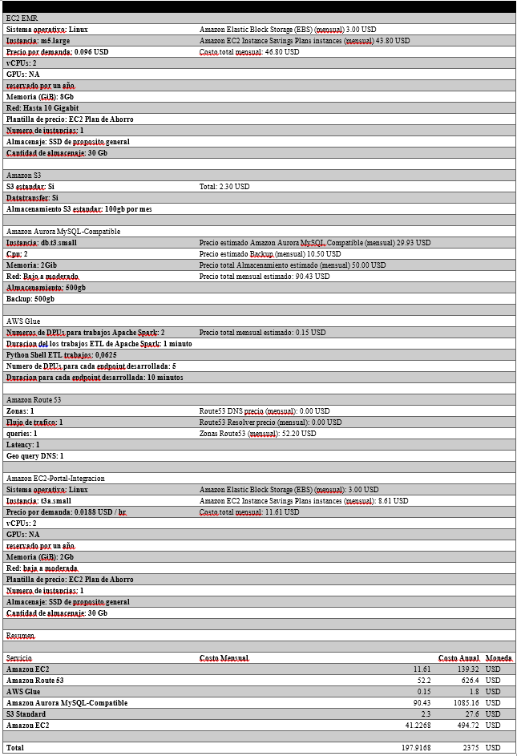

Presupuesto